# CASTfxn Vignette

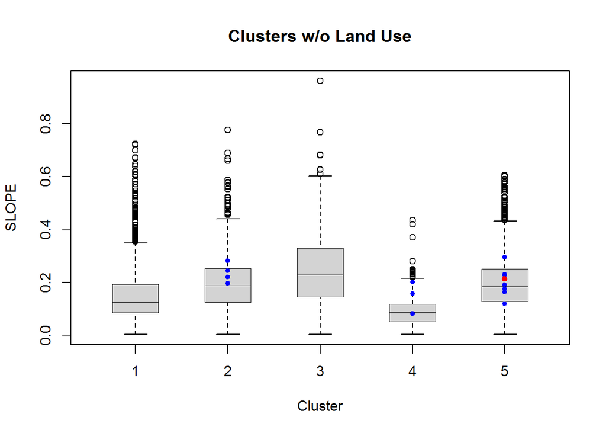

```
## [1] "Processing item, 84/95; SWs"
```

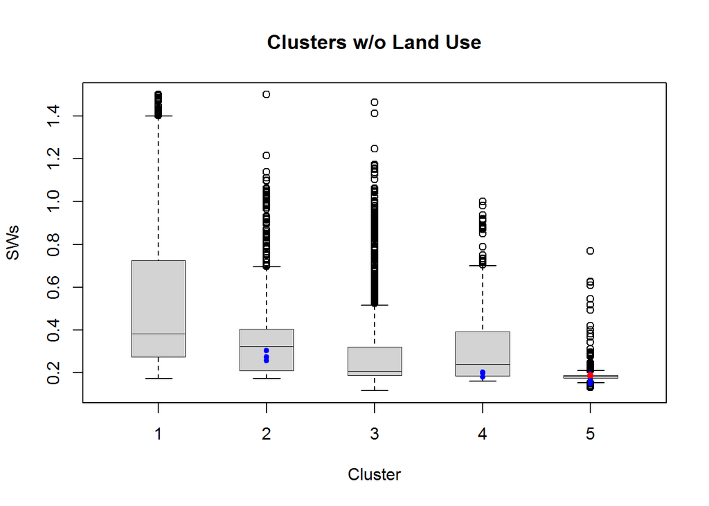

```
## [1] "Processing item, 85/95; clust"
```

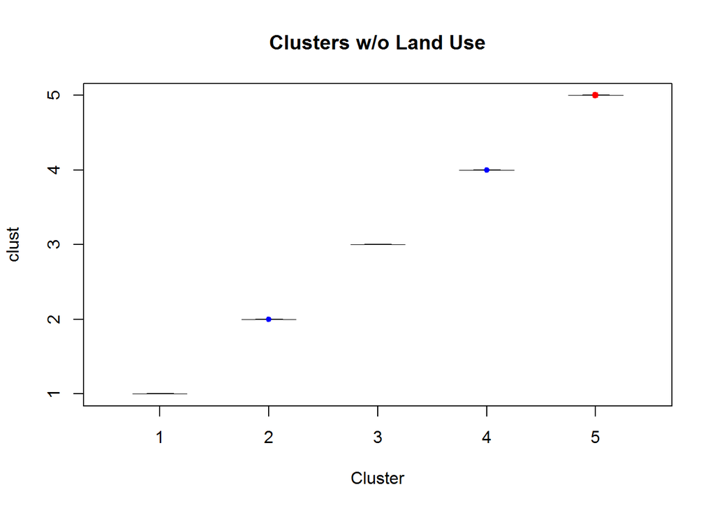

```
## [1] "Processing item, 86/95; H6_noland"
## [1] "No data, next"
## [1] "Processing item, 87/95; H6_land"
## [1] "No data, next"
## [1] "Processing item, 88/95; PrecipWs"
```

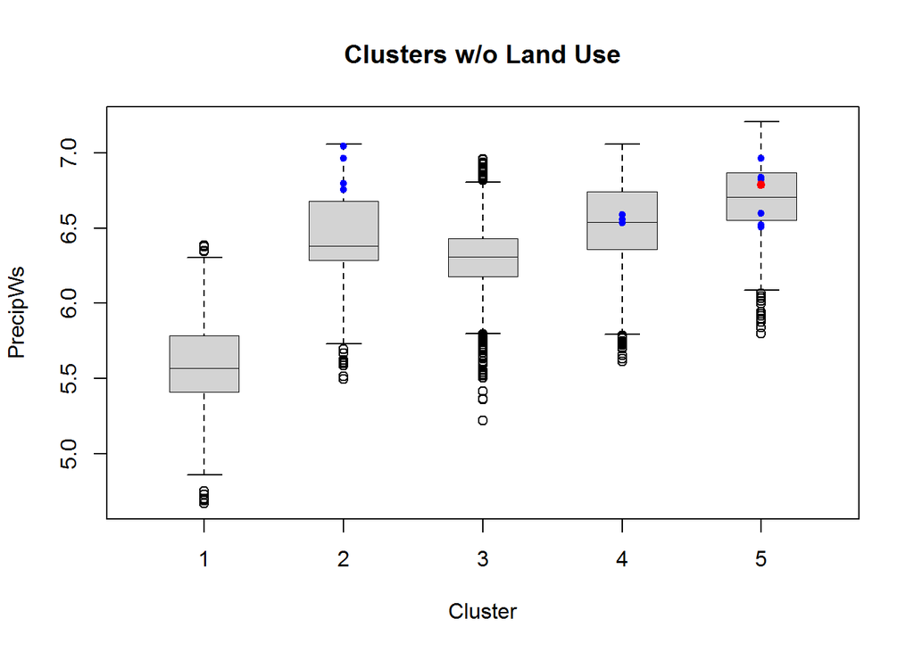

```
## [1] "Processing item, 89/95; TmeanWs"
```

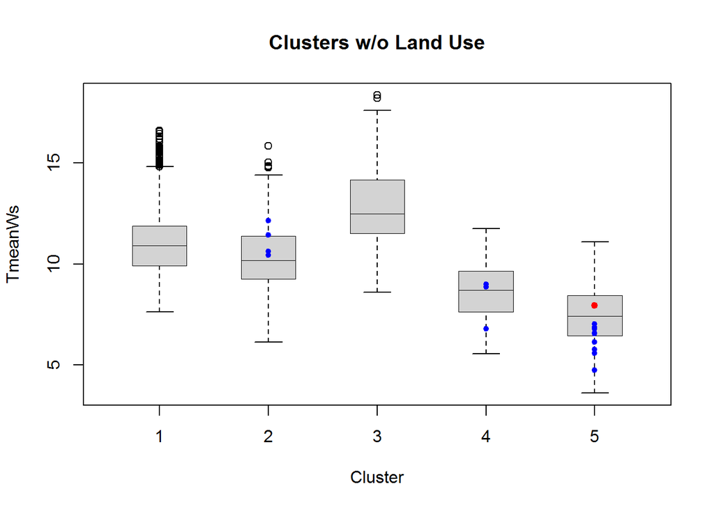

```
## [1] "Processing item, 90/95; W___AGRIC"
## [1] "No data, next"
## [1] "Processing item, 91/95; W___URBAN"
## [1] "No data, next"
## [1] "Processing item, 92/95; W___FOREST"
## [1] "No data, next"
## [1] "Processing item, 93/95; clust_noland"
```

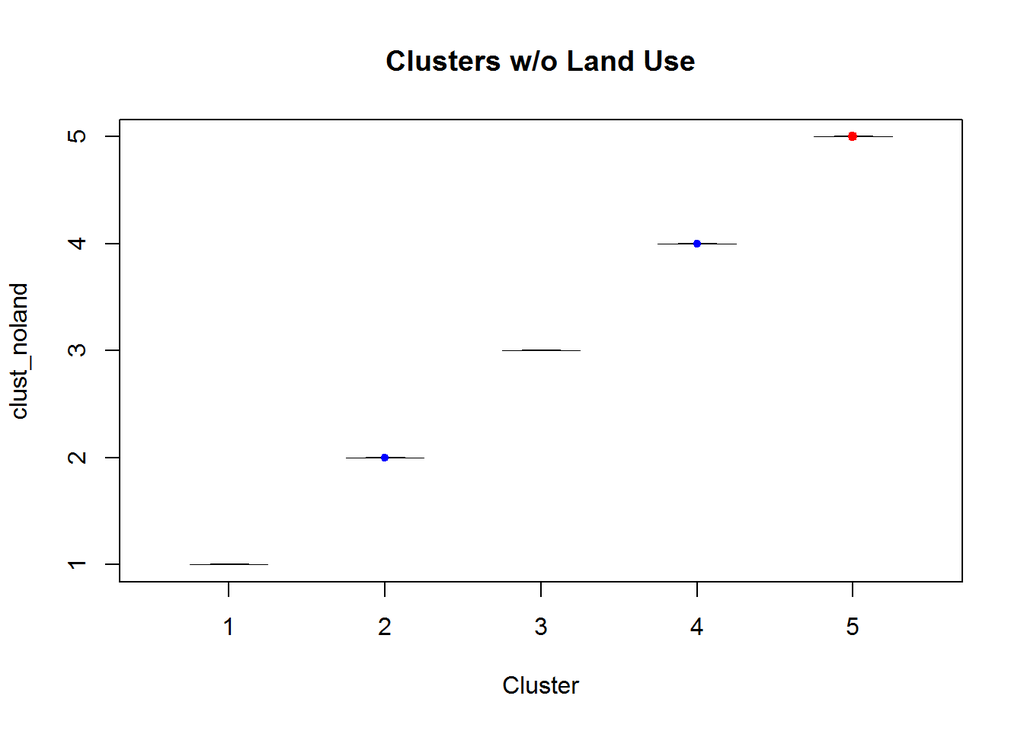

```
## [1] "Processing item, 94/95; clust_land"
```

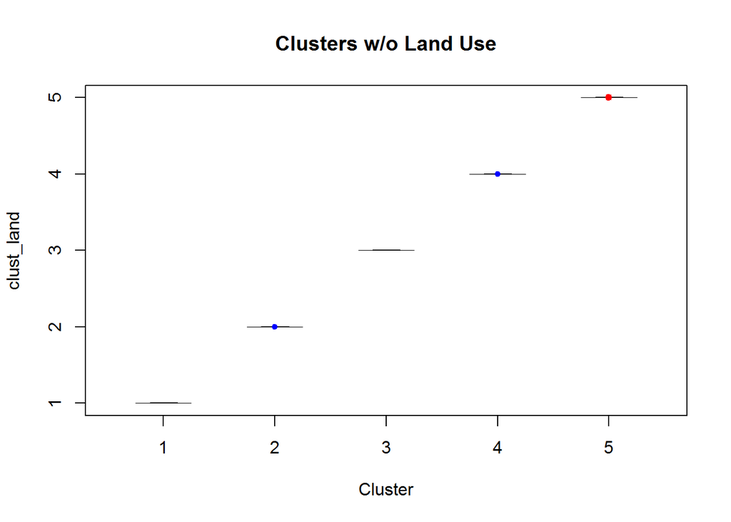

```
## [1] "Processing item, 95/95; ElevCategory"
## [1] "No data, next"
```

For each variable in the test data set a “Ws” (Watershed) and “Cat” (Catchment) version are created. This is how the variables exist in the data.

- Ws = watershed = entire upstream area
- Cat = catchment = local polygon associated with reach

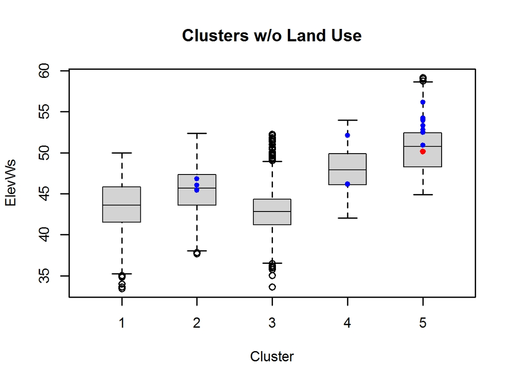

```r
TargetSiteID <- "SRCKN001.61"
myJPG <- paste0(TargetSiteID,".cluster.ElevWs.jpg")
fn.img <- file.path(getwd(), "Results", TargetSiteID, myJPG)
include_graphics(fn.img)
```

### getBMImatches

Get BMI and chem sample matches.

Requires the output of:

- getSiteInfo
- getChemDataSubsets
- getStressorList

The return is a summary list; all.b.str, cl.b.str, site.b.str, all.b.rsp , cl.b.rsp, and site.b.rsp. No files are created or saved.

```r
TargetSiteID <- "SRCKN001.61"
clustertype <- "5"
useLU <- FALSE

CurrentDir<-getwd()
myDir.Data <- paste(CurrentDir,"data/",sep="/")

# datasets getSiteInfo
# data, example included with package
data.Stations.Info <- data_Sites
data.SampSummary   <- data_SampSummary
data.303d.ComID    <- data_303d
data.bmi.metrics   <- data_BMIMetrics
data.algae.metrics <- data_AlgMetrics
data.cluster       <- data_Cluster_Hi
data.mod           <- data_ReachMod
#
# Run getSiteInfo
list.SiteSummary <- getSiteInfo(TargetSiteID, clustertype, useLU)

# datasets getChemDataSubsets
site.COMID <- list.SiteSummary$COMID
site.Clusters <- list.SiteSummary$ClustIDs

# data, example included with package
data.chem.raw <- data_Chem
data.chem.info <- data_ChemInfo

# Run getChemDataSubsets
list.data <- getChemDataSubsets(TargetSiteID, site.COMID, site.Clusters, clustertype, useLU)

# datasets getStressorList
chem.info <- list.data$chem.info
cluster.chem <- list.data$cluster.chem
cluster.samps <- list.data$cluster.samps
ref.sites <- list.data$ref.sites
site.chem <- list.data$site.chem

# set cutoff for possible stressor identification
probsLow <- 0.10
probsHigh <- 0.90

# Run getStressorList
list.stressors <- getStressorList(TargetSiteID, site.Clusters, chem.info, cluster.chem
                                 , cluster.samps, ref.sites, site.chem
                                 , probsHigh, probsLow)
```

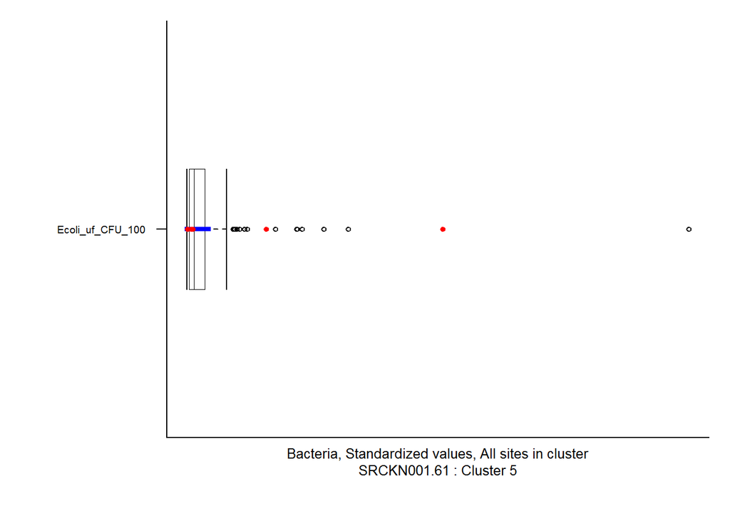

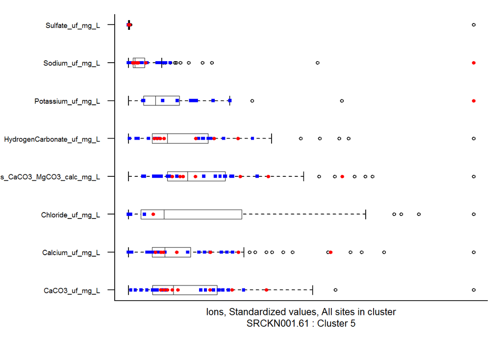

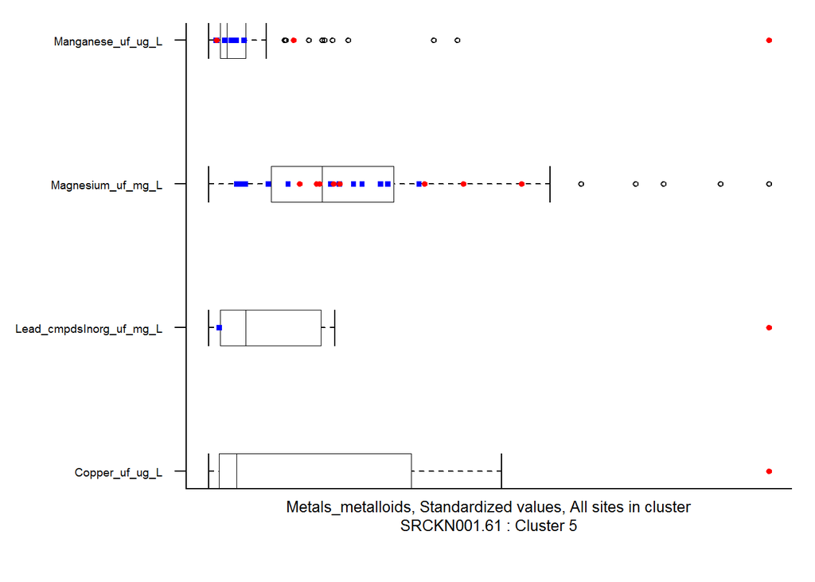

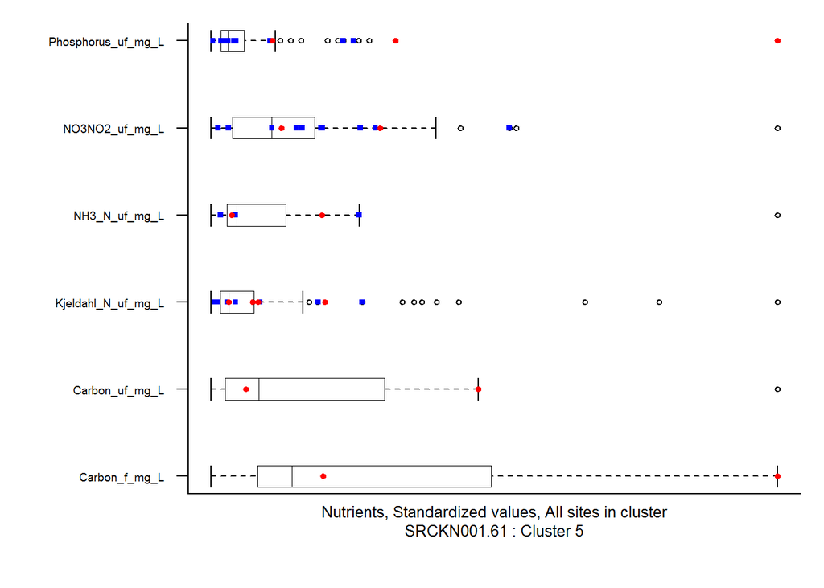

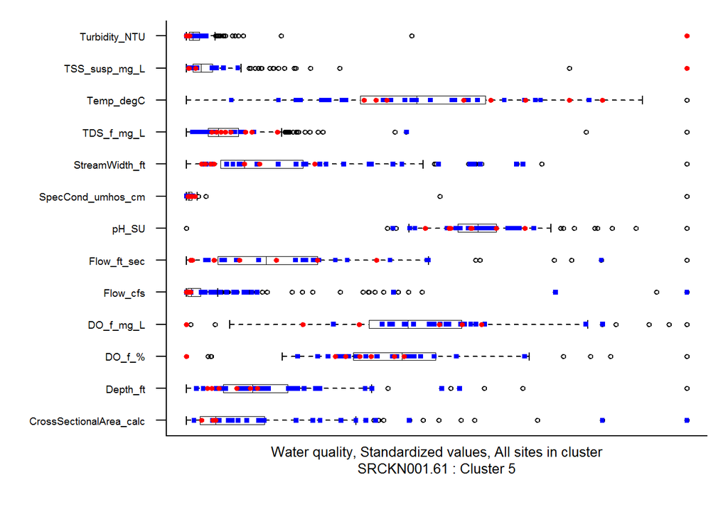

```r
# datasets getBMIMatches
## remove "none"
stressors <- list.stressors$stressors[list.stressors$stressors != "none"]


# Run getBMIMatches
list.MatchBMIData <- getBMIMatches(stressors, list.data)
```

The structure of the returned data is below.

```r
str(list.MatchBMIData)
```

```
## List of 6
##  $ all.b.str :'data.frame':  172 obs. of  26 variables:
##   ..$ ChemSampleID                  : chr [1:172] "LCBEN002.57_2007-05-09" "LCBIL000.15_2014-05-13" "LCBIL000.15_2014-05-13" "LCBRB006.74_2007-06-18" ...
##   ..$ BMI.Metrics.SampID            : chr [1:172] "LCBEN002.57_2007-05-09_3348_1" "LCBIL000.15_2014-05-13_3898_1" "LCBIL000.15_2014-05-13_3898_2" "LCBRB006.74_2007-06-18_3349_1" ...
##   ..$ StationID_Master              : Factor w/ 441 levels "BWBOU007.83",..: 40 42 42 45 45 49 49 50 53 54 ...
##   ..$ Arsenic_inorg_uf_ug_L         : num [1:172] NA 1.35 1.35 NA NA 3.1 3.7 5.4 NA NA ...
##   ..$ CaCO3_uf_mg_L                 : num [1:172] 73 NA NA 46 NA 91 NA 150 NA 280 ...
##   ..$ Calcium_uf_mg_L               : num [1:172] 13 31.7 31.7 9 11.1 21 30.9 30 19.3 43 ...
##   ..$ Carbon_f_mg_L                 : num [1:172] NA NA NA NA NA NA NA NA NA NA ...
##   ..$ Carbon_uf_mg_L                : num [1:172] NA NA NA NA NA NA NA NA NA NA ...
##   ..$ Copper_uf_ug_L                : num [1:172] NA NA NA NA NA NA NA NA NA NA ...
##   ..$ Ecoli_uf_CFU_100              : num [1:172] NA 14.1 14.1 9.3 52.6 ...
##   ..$ Hardness_CaCO3_MgCO3_calc_mg_L: num [1:172] 55.5 164.5 164.5 41 50.9 ...
##   ..$ Kjeldahl_N_uf_mg_L            : num [1:172] NA 0.465 0.465 0.24 0.54 NA 0.68 0.21 0.68 0.27 ...
##   ..$ Lead_cmpdsInorg_uf_mg_L       : num [1:172] NA NA NA NA NA NA NA NA 0.001 NA ...
##   ..$ Magnesium_uf_mg_L             : num [1:172] 5.6 20.7 20.7 4.5 5.63 8.5 13.5 14 8.72 32 ...
##   ..$ Manganese_uf_ug_L             : num [1:172] NA 26.5 26.5 NA 15.3 NA 4.3 NA 14.8 55 ...
##   ..$ NO3NO2_uf_mg_L                : num [1:172] NA NA NA NA NA NA NA 0.026 NA NA ...
##   ..$ pH_SU                         : num [1:172] 8.08 8.27 8.27 7.89 7.39 ...
##   ..$ Phosphorus_uf_mg_L            : num [1:172] 0.04 0.026 0.026 0.02 NA NA NA 0.03 0.11 0.02 ...
##   ..$ Potassium_uf_mg_L             : num [1:172] 1.1 NA NA NA NA NA 0.753 0.77 1.21 3.7 ...
##   ..$ Sodium_uf_mg_L                : num [1:172] 6 13.25 13.25 1.2 1.26 ...
##   ..$ SpecCond_umhos_cm             : num [1:172] 142 338 338 90 104 ...
##   ..$ Sulfate_uf_mg_L               : num [1:172] 1.1 6.3 6.3 NA 1.4 NA 1.6 NA 7.4 350 ...
##   ..$ TDS_f_mg_L                    : num [1:172] 89.5 198 198 54 66 ...
##   ..$ Temp_degC                     : num [1:172] 5.55 14.59 14.59 25.91 11.25 ...
##   ..$ TSS_susp_mg_L                 : num [1:172] NA 5.97 5.97 NA 1.4 0.966 2.69 NA 4.38 25 ...
##   ..$ Turbidity_NTU                 : num [1:172] 2.75 2.49 2.49 2 1.57 1.53 0.89 1.11 3.63 NA ...
##  $ cl.b.str  :'data.frame':  64 obs. of  26 variables:
##   ..$ ChemSampleID                  : chr [1:64] "LCBEN002.57_2007-05-09" "LCBIL000.15_2014-05-13" "LCBIL000.15_2014-05-13" "LCCOL003.03_2014-05-21" ...
##   ..$ BMI.Metrics.SampID            : chr [1:64] "LCBEN002.57_2007-05-09_3348_1" "LCBIL000.15_2014-05-13_3898_1" "LCBIL000.15_2014-05-13_3898_2" "LCCOL003.03_2014-05-21_3901_1" ...
##   ..$ StationID_Master              : Factor w/ 441 levels "BWBOU007.83",..: 40 42 42 53 59 60 61 62 62 63 ...
##   ..$ Arsenic_inorg_uf_ug_L         : num [1:64] NA 1.35 1.35 NA NA NA NA NA NA NA ...
##   ..$ CaCO3_uf_mg_L                 : num [1:64] 73 NA NA NA 57 NA 21 17 NA 50 ...
##   ..$ Calcium_uf_mg_L               : num [1:64] 13 31.7 31.7 19.3 10 NA 3.6 3.4 NA 11 ...
##   ..$ Carbon_f_mg_L                 : num [1:64] NA NA NA NA NA NA NA NA NA NA ...
##   ..$ Carbon_uf_mg_L                : num [1:64] NA NA NA NA NA NA NA NA NA NA ...
##   ..$ Copper_uf_ug_L                : num [1:64] NA NA NA NA NA NA NA NA NA NA ...
##   ..$ Ecoli_uf_CFU_100              : num [1:64] NA 14.1 14.1 NA 263 ...
##   ..$ Hardness_CaCO3_MgCO3_calc_mg_L: num [1:64] 55.5 164.5 164.5 84.1 41 ...
```

[output cut: 129 more lines]

```
##   ..$ IntolTaxSPL_Sc    : num [1:2] 0 33.3
##   ..$ HBISPL_Sc         : num [1:2] 65.7 78.9
##   ..$ PlecoPct_Sc       : num [1:2] 5.55 66.89
##   ..$ ScrapPctSPL_Sc    : num [1:2] 1.18 16.24
##   ..$ ScrapTaxSPL_Sc    : num [1:2] 18.2 54.5
##   ..$ TrichTax_Sc       : num [1:2] NA NA
##   ..$ EphemTax_Sc       : num [1:2] NA NA
##   ..$ EphemPct_Sc       : num [1:2] NA NA
##   ..$ Dom01PctSPL_Sc    : num [1:2] NA NA
##   ..$ CollDate          : Date[1:2], format: "2012-06-19" ...
##   ..$ BMISampID         : chr [1:2] "SRCKN001.61_2012-06-19_3840_1" "SRCKN001.61_2013-06-11_3872_1"
##   ..$ CSCI              : num [1:2] 24.3 52
##   ..$ O_E               : chr [1:2] NA NA
##   ..$ MMI_Score         : num [1:2] 24.3 52
##   ..$ ElevCategory      : chr [1:2] "HI" "HI"
```

### getBMIStressorResponses

Get BMI stressor responses.

Requires the output of:

- getSiteInfo
- getChemDataSubsets
- getStressorList
- getBMImatches

The return is jpg in “Results” folder of working directory for each parameter. And a tab-delimited text file of stressor correlations.

The jpg files are in teh format of SiteID.BMI.SR.parameter.jpg, e.g., SRCKN001.61BMI.SR.Arsenic_inorg_uf_ug_L_DipTaxSPL_Sc.jpg.

```r
predint <- 0.75
varLegLoc <- "topright"
BMIresp <- c("CSCI", "MMI_Score", "TotalTaxSPL_Sc", "DipTaxSPL_Sc"
             , "IntolTaxSPL_Sc", "HBISPL_Sc", "PlecoPct_Sc", "ScrapPctSPL_Sc"
             , "TrichTax_Sc", "EphemTax_Sc", "EphemPct_Sc", "Dom01PctSPL_Sc")

TargetSiteID <- "SRCKN001.61"
clustertype <- "5"
useLU <- FALSE

CurrentDir<-getwd()
myDir.Data <- paste(CurrentDir,"data/",sep="/")

# datasets getSiteInfo
# data, example included with package
data.Stations.Info <- data_Sites
data.SampSummary   <- data_SampSummary
data.303d.ComID    <- data_303d
data.bmi.metrics   <- data_BMIMetrics
data.algae.metrics <- data_AlgMetrics
data.cluster       <- data_Cluster_Hi
data.mod           <- data_ReachMod
#
# Run getSiteInfo
list.SiteSummary <- getSiteInfo(TargetSiteID, clustertype, useLU)

# datasets getChemDataSubsets
site.COMID <- list.SiteSummary$COMID
site.Clusters <- list.SiteSummary$ClustIDs

# data, example included with package
data.chem.raw <- data_Chem
data.chem.info <- data_ChemInfo

# Run getChemDataSubsets
list.data <- getChemDataSubsets(TargetSiteID, site.COMID, site.Clusters, clustertype, useLU)

# datasets getStressorList
chem.info <- list.data$chem.info
cluster.chem <- list.data$cluster.chem
cluster.samps <- list.data$cluster.samps
ref.sites <- list.data$ref.sites
site.chem <- list.data$site.chem

# set cutoff for possible stressor identification
probsLow <- 0.10
probsHigh <- 0.90

# Run getStressorList
list.stressors <- getStressorList(TargetSiteID, site.Clusters, chem.info, cluster.chem
                                 , cluster.samps, ref.sites, site.chem
                                 , probsHigh, probsLow)

# datasets getBMIMatches
## remove "none"
stressors <- list.stressors$stressors[list.stressors$stressors != "none"]

# Run getBMIMatches
list.MatchBMIData <- getBMIMatches(stressors, list.data)

# Run getBMIStressorResponses
getBMIStressorResponses(stressors, list.MatchBMIData)
```

The structure of the returned data is below.

```r
str(list.MatchBMIData)
```

### getAlgMatches

Get Algae and chem sample matches.

Requires the output of:

- getSiteInfo
- getChemDataSubsets
- getStressorList

The return is a summary list; all.b.str, cl.b.str, site.b.str, all.b.rsp, cl.b.rsp , and site.b.rsp.

The example data included with the package does not include algal data so no outputs are produced. The output is similar to getBMImatches.

```r
TargetSiteID <- "SRCKN001.61"
clustertype <- "5"
useLU <- FALSE

CurrentDir<-getwd()
myDir.Data <- paste(CurrentDir,"data/",sep="/")

# datasets getSiteInfo
# data, example included with package
data.Stations.Info <- data_Sites
data.SampSummary   <- data_SampSummary
data.303d.ComID    <- data_303d
data.bmi.metrics   <- data_BMIMetrics
data.algae.metrics <- data_AlgMetrics
data.cluster       <- data_Cluster_Hi
data.mod           <- data_ReachMod
#
# Run getSiteInfo
list.SiteSummary <- getSiteInfo(TargetSiteID, clustertype, useLU)

# datasets getChemDataSubsets
site.COMID <- list.SiteSummary$COMID
site.Clusters <- list.SiteSummary$ClustIDs

# data, example included with package
data.chem.raw <- data_Chem
data.chem.info <- data_ChemInfo

# Run getChemDataSubsets
list.data <- getChemDataSubsets(TargetSiteID, site.COMID, site.Clusters, clustertype, useLU)

# datasets getStressorList
chem.info <- list.data$chem.info
cluster.chem <- list.data$cluster.chem
cluster.samps <- list.data$cluster.samps
ref.sites <- list.data$ref.sites
site.chem <- list.data$site.chem

# set cutoff for possible stressor identification
probsLow <- 0.10
probsHigh <- 0.90

# Run getStressorList
list.stressors <- getStressorList(TargetSiteID, site.Clusters, chem.info, cluster.chem
                                 , cluster.samps, ref.sites, site.chem
                                 , probsHigh, probsLow)

# datasets getAlgMatches
## remove "none"
stressors <- list.stressors$stressors[list.stressors$stressors != "none"]

# Run getAlgMatches
list.MatchAlgData <- getAlgMatches(stressors, list.data)
```

The structure of the returned data is below.

```r
str(list.MatchAlgData)
```

### getAlgStressorResponses

Algae stressor regressions.

Requires the output of:

- getSiteInfo
- getChemDataSubsets
- getStressorList
- getAlgMatches

The return is a jpg in “Results” folder of working directory for each paramter. And a tab-delimited text file of stressor correlations.

The example data included with the package does not include algal data so no outputs are produced. The output is similar to getBMIStressorResponses

```r
predint <- 0.75
varLegLoc <- "topright"

TargetSiteID <- "SRCKN001.61"
clustertype <- "5"
useLU <- FALSE

CurrentDir<-getwd()
myDir.Data <- paste(CurrentDir,"data/",sep="/")

# datasets getSiteInfo
# data, example included with package
data.Stations.Info <- data_Sites
data.SampSummary   <- data_SampSummary
data.303d.ComID    <- data_303d
data.bmi.metrics   <- data_BMIMetrics
data.algae.metrics <- data_AlgMetrics
data.cluster       <- data_Cluster_Hi
data.mod           <- data_ReachMod
#
# Run getSiteInfo
list.SiteSummary <- getSiteInfo(TargetSiteID, clustertype, useLU)

# datasets getChemDataSubsets
site.COMID <- list.SiteSummary$COMID
site.Clusters <- list.SiteSummary$ClustIDs

# data, example included with package
data.chem.raw <- data_Chem
data.chem.info <- data_ChemInfo

# Run getChemDataSubsets
list.data <- getChemDataSubsets(TargetSiteID, site.COMID, site.Clusters, clustertype, useLU)

# datasets getStressorList
chem.info <- list.data$chem.info
cluster.chem <- list.data$cluster.chem
cluster.samps <- list.data$cluster.samps
ref.sites <- list.data$ref.sites
site.chem <- list.data$site.chem

# set cutoff for possible stressor identification
probsLow <- 0.10
probsHigh <- 0.90

# Run getStressorList
list.stressors <- getStressorList(TargetSiteID, site.Clusters, chem.info, cluster.chem
                                 , cluster.samps, ref.sites, site.chem
                                 , probsHigh, probsLow)

# datasets getAlgMatches
## remove "none"
stressors <- list.stressors$stressors[list.stressors$stressors != "none"]

# Run getAlgMatches
list.MatchAlgData <- getAlgMatches(stressors, list.data)

# data getAltStressorResponses
data.algae.metrics <- data_AlgMetrics
AlgResp <- colnames(data.algae.metrics[4:ncol(data.algae.metrics)])
predint <- 0.75
varLegLoc <- "topright"

# Run getAlgStressorResponses
getAlgStressorResponses(stressors, list.MatchAlgData)
```

The structure of the returned data is below.

```r
str(list.MatchAlgData)
```

### getStressorSpecificRegressions

Get stressor specific regressions.

Requires the output of:

- getSiteInfo
- getChemDataSubsets
- getStressorList
- getBMImatches

The return is Jpeg files to “Results” folder in working directory. And a tab-delimited text file.

```r
predint <- 0.75
varLegLoc <- "topright"

TargetSiteID <- "SRCKN001.61"
clustertype <- "5"
useLU <- FALSE

CurrentDir <- getwd()
myDir.Data <- paste(CurrentDir,"data/",sep="/")

# datasets getSiteInfo
# data, example included with package
data.Stations.Info <- data_Sites
data.SampSummary   <- data_SampSummary
data.303d.ComID    <- data_303d
data.bmi.metrics   <- data_BMIMetrics
data.algae.metrics <- data_AlgMetrics
data.cluster       <- data_Cluster_Hi
data.mod           <- data_ReachMod
#
# Run getSiteInfo
list.SiteSummary <- getSiteInfo(TargetSiteID, clustertype, useLU)

# datasets getChemDataSubsets
site.COMID <- list.SiteSummary$COMID
site.Clusters <- list.SiteSummary$ClustIDs

# data import, example
# data.chem.raw <- read.delim(paste(myDir.Data,"data.chem.raw.tab",sep=""),na.strings = c(""," "))
# data.chem.info <- read.delim(paste(myDir.Data,"data.chem.info.tab",sep=""))

# data, example included with package
data.chem.raw <- data_Chem
data.chem.info <- data_ChemInfo

# Run getChemDataSubsets
list.data <- getChemDataSubsets(TargetSiteID, site.COMID, site.Clusters, clustertype, useLU)

# datasets getStressorList
chem.info <- list.data$chem.info
cluster.chem <- list.data$cluster.chem
cluster.samps <- list.data$cluster.samps
ref.sites <- list.data$ref.sites
site.chem <- list.data$site.chem

# set cutoff for possible stressor identification
probsLow <- 0.10
probsHigh <- 0.90

# Run getStressorList
list.stressors <- getStressorList(TargetSiteID, site.Clusters, chem.info, cluster.chem
                                 , cluster.samps, ref.sites, site.chem
                                 , probsHigh, probsLow)

# datasets getBMIMatches
## remove "none"
stressors <- list.stressors$stressors[list.stressors$stressors != "none"]

# Run getBMIMatches
list.MatchBMIData <- getBMIMatches(stressors, list.data)

# datasets getStressorSpecificRegressions
# data import, example
# data.bmi.taxa.raw <- read.delim(paste(myDir.Data,"data.bmi.taxa.raw.tab",sep=""))
# data.SSTV.totabund <- read.delim(paste(myDir.Data,"data.totabund.bySample.tab",sep=""))
#
# data, example included with package
data.bmi.taxa.raw <- data_BMIcounts
data.SSTV.totabund <- data_BMIRelAbund

# Run getStressorSpecificRegressions
getStressorSpecificRegressions(list.MatchBMIData)
```

The structure of the returned data is below.

```r
str(list.MatchAlgData)
```

### getSSDplot

Species Sensitify Distribution (SSD) plots

Generates plots of the proportion of species affected at different exposure levels in laboratory toxicity tests.

Plots are generated from a single set of inputs. They are created with ggplot and are returned to the console as a variable (e.g., “p1”). It is up to the user to save the output.

The plot below reproduces the plot contained in the ssd_generator_v1.xlsm file on the CADDIS website.

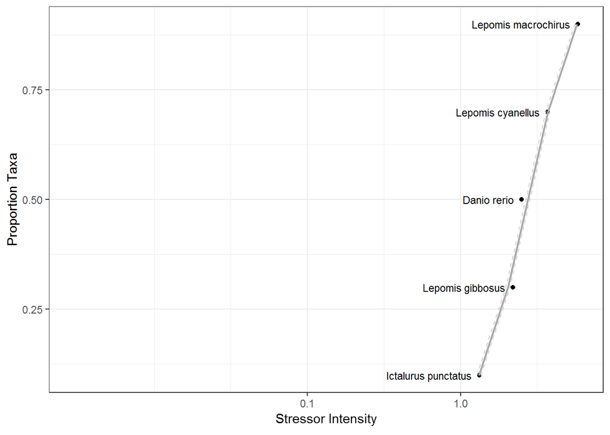

```r
# Example 3
# https://www.epa.gov/caddis-vol4/caddis-volume-4-data-analysis-download-software
# ssd_generator_v1.xlsm
myDF <- data_SSD_generator
myRT   <- "ResponseType"
myTaxa <- "Taxa"
myExp  <- "Exposure"
# Run function
p3 <- getSSDplot(myDF, myRT, myTaxa, myExp)
p3
```

For information on interpretation see the CADDIS website.

https://www.epa.gov/caddis-vol4/caddis-volume-4-data-analysis-advanced-analyses-controlling-for-natural-variability#tab-5

### getCoOccur

Generates a PDF with 2 plots per site for co-occurrence of measured chem and bio data.

Saves PDF of plots and a scores files (tab separated) to user defined directory. Each SiteID is a different directory.

The example data for this function is from a different state from the other example data so SiteID’s and stressor data will not match.

```r
#Load Data
df.data <- data_CoOccur
#
col.Group     <- "Group"
col.Bio       <- "CSCI"
col.Stressors <- c("DO_uf_mg_L", "SpecCond_uf_µS_cm", "TN_uf_mg_L", "TP_mg_L")
col.ID        <- c("StationID_Master")
#
Bio.Nar.Brk <- c(-2, 0.62, 0.799, 0.919, 2)
Bio.Nar.Lab <- c("very likely altered", "likely altered"
                , "possibly altered ", "likely intact")
Bio.Deg.Brk <- c(-2, 0.799, 2)
Bio.Deg.Lab <- c("Degraded", "Good")
dir.plots <- file.path(getwd(), "Results")
#
ID.plot <- c("SMC08335", "901SJSJC9", "911TCAM01", "403STC004")
#
getCoOccur(df.data, ID.plot, col.ID, col.Group, col.Bio, col.Stressors
        , Bio.Nar.Brk, Bio.Nar.Lab, Bio.Deg.Brk, Bio.Deg.Lab
        , dir.plots
        )
```

The output is a PDF with a box plot of **within** cluster data for a single parameter where the biological score was better than the test site. Points are the data that contribute to the box plot but are color coded by biological condition; Degraded (gray) and Good (cyan). The red dashed line represents the parameter value of the test site. If there are multiple lines then there are multiple samples for the test site. The x-axis has the name of the parameter, the number of comparator sites (n), and the cooccurrence score for the site.

The second plot is the relative probablity of degraded condition. The red dashed line is the value of the parameter at the test site. The lines are the 20th and 50th percentiles.

The scores text file has the biological score, cluster, parameter, value,  
statistics for the cluster (number of samples, 25th-, 50th-, and 75th-percentiles), and the cooccurence score.

(In ext data folder) 901SJSJC9.CoOccurrence_Scores_20180802_123825.tsv

901SJSJC9_CoOccurrence_20180802_123825.pdf

system(’open “901SJSJC9_CoOccurrence_20180802_123825.pdf”)

file.path(path.package(“CASTfxn”), “extdata”)

```r
dir.pkg <- file.path(path.package("CASTfxn"), "extdata")
fn.pdf <- file.path(dir.pkg, "901SJSJC9_CoOccurrence_20180802_123825.pdf")
fn.tsv <- file.path(dir.pkg, "901SJSJC9.CoOccurrence_Scores_20180802_123825.tsv")
fn.jpg <- file.path(dir.pkg, "901SJSJC9_CoOccurrence_DO.jpg")
#
# Open PDF
#system(paste0("open ",fn.pdf, ""))
#
# data table
df.tsv <- read.delim(fn.tsv)
kable(df.tsv, caption="CoOccurence Scores")
```

CoOccurence Scores

| StationID_Master | Group | CSCI | Bio.Nar | Bio.Deg | Param_Name | Param_Value | n | q25 | q50 | q75 | Sc_Comp |
| --- | --- | --- | --- | --- | --- | --- | --- | --- | --- | --- | --- |
| 901SJSJC9 | 3 | 0.57 | very likely altered | Degraded | DO_uf_mg_L | 8.95 | 40 | 7.500 | 9.27 | 10.48 | -1 |
| 901SJSJC9 | 3 | 0.57 | very likely altered | Degraded | SpecCond_uf_µS_cm | 594.00 | 78 | 1095.000 | 1765.50 | 2731.00 | -1 |
| 901SJSJC9 | 3 | 0.57 | very likely altered | Degraded | SpecCond_uf_µS_cm | 1471.00 | 78 | 1095.000 | 1765.50 | 2731.00 | -1 |
| 901SJSJC9 | 3 | 0.57 | very likely altered | Degraded | SpecCond_uf_µS_cm | 2244.00 | 78 | 1095.000 | 1765.50 | 2731.00 | 0 |
| 901SJSJC9 | 3 | 0.57 | very likely altered | Degraded | SpecCond_uf_µS_cm | 2678.00 | 78 | 1095.000 | 1765.50 | 2731.00 | 0 |
| 901SJSJC9 | 3 | 0.57 | very likely altered | Degraded | SpecCond_uf_µS_cm | 2879.00 | 78 | 1095.000 | 1765.50 | 2731.00 | 1 |
| 901SJSJC9 | 3 | 0.57 | very likely altered | Degraded | TN_uf_mg_L | 0.85 | 43 | 0.835 | 2.22 | 6.30 | -1 |

```r
#
# image
#include_graphics(fn.jpg)
```

[output not shown]

# Output

It is up to the user to interpret the output of CAST. CAST is meant as a screening tool so the user will need to use best professional judgment to draw any conclusions.

## Code

Example code is below to generate the outputs from each of the CAST functions. This example uses a mix of the internal example data files and user files.

```r
# Install CASTfxn ####
# library(devtools)
# install_github("ALincolnTt/CASTfxn")

# Set up ####
library(CASTfxn)
library(readxl)

#Dir.Base <- "C:/Users/ann.lincoln/OneDrive - Tetra Tech, Inc/_ActiveProjects/AZ/RCodeData/ChemData"
#Dir.Base <- "P:/Current/OtherGov/City of San Diego/FY2018/CAST_2018/QC_20180705/data"
Dir.Base <- "C:/Users/Erik.Leppo/OneDrive - Tetra Tech, Inc/MyDocs_OneDrive/GitHub/CASTfxn/vignettes/Results"
#setwd("C:\\Users\\Erik.Leppo\\OneDrive - Tetra Tech, Inc\\MyDocs_OneDrive\\GitHub\\CASTfxn_Ann\\CASTfxn")

#Dir.Base <- "C:\\Users\\Erik.Leppo\\OneDrive - Tetra Tech, Inc\\MyDocs_OneDrive\\SanDiego\\Results"
setwd(Dir.Base)

# Site Selection ####
TargetSiteID <- "LCNUT011.29"  # "VRELL009.02"
TargetElevation <- "HI"

# Read Files ####
#Read all data files
data.SampSummary <- data_SampSummary
data.mod         <- data_ReachMod
data.chem.info   <- data_ChemInfo
data.303d.ComID  <- data_303d

# Subset ####
# These need subsetting
if (TargetElevation == "HI") {
    data.cluster   <- data_Cluster_Hi
    fn.coOccur.hi  <- file.path(Dir.Base,"AZCoOccurData_HI.tab")
    data.coOccur   <- read.table(fn.coOccur.hi, header = TRUE, sep = "\t")
    ibi.thresholds <- c(45,52)
} else {
    data.cluster   <- data_Cluster_Lo
    fn.coOccur.lo  <- file.path(Dir.Base, "AZCoOccurData_LO.tab")
    data.coOccur   <- read.table(fn.coOccur.lo, header = TRUE, sep = "\t")
    ibi.thresholds <- c(39,50)
}

# CAST, Stations ####
data.Stations.Info <- data_Sites
data.Stations.Info <- data.Stations.Info[data.Stations.Info$ElevCategory == TargetElevation,]

# CAST, Chem ####
## Use data rather than example file
data.chem.raw <- data_Chem
#
fn.cheminfo2   <- file.path(Dir.Base, "AZStressorInfoFinal.xlsx")
data.chem.info2 <- read_excel(fn.cheminfo2, sheet = 1, skip = 0)
# #
# fn.chem <- file.path(Dir.Base, "AZStressorDataFinal.tab")
# data.chem.raw <- read.delim(fn.chem, na.strings = "NA")
#
analytes      <- data.chem.info$StdParamName[data.chem.info$UseInStressorID == 1]
data.chem.raw <- data.chem.raw[data.chem.raw$StdParamName %in% analytes,]
data.chem.raw <- data.chem.raw[data.chem.raw$ElevCategory == TargetElevation,]

# CAST, BMI, metrics ####
data.bmi.metrics <- data_BMIMetrics
data.bmi.metrics <- data.bmi.metrics[data.bmi.metrics$ElevCategory == TargetElevation,]
data.bmi.metrics <- data.bmi.metrics[data.bmi.metrics$StationID_Master != "VROAK042.78",]
data.bmi.metrics <- data.bmi.metrics[data.bmi.metrics$StationID_Master != "SRHAG007.47",]
data.bmi.metrics <- data.bmi.metrics[,c("StationID_Master","BMISampID",
                                        "BMI.Metrics.SampID","CollDate",
                                        "ElevCategory","NarRat","IBI",
                                        "TotalTaxSPL_Sc","DipTaxSPL_Sc",
                                        "IntolTaxSPL_Sc","HBISPL_Sc","PlecoPct_Sc",
                                        "ScrapPctSPL_Sc","ScrapTaxSPL_Sc",
                                        "TrichTax_Sc","EphemTax_Sc","EphemPct_Sc",
                                        "Dom01PctSPL_Sc")]
data.bmi.metrics <- data.bmi.metrics[, unlist(lapply(data.bmi.metrics,
                                      function(x) !all(is.na(x))))]

# CAST, Alg, metrics ####
fn.alg.metrics     <- file.path(Dir.Base, "AZAlgaeMetrics.tab")
data.algae.metrics <- read.table(fn.alg.metrics, header = TRUE, sep = "\t")
data.algae.metrics <- data.algae.metrics[!is.na(data.algae.metrics),]

# CAST, misc ####
fn.bmi.raw        <- file.path(Dir.Base, "AZBenthicCountsFinal.tab")
data.bmi.taxa.raw <- read.table(fn.bmi.raw, header = TRUE, sep = "\t")

fn.MT.bmi   <- file.path(Dir.Base, "AZBenthicMasterTaxa.tab")
data.MT.bmi <- read.table(fn.MT.bmi, header = TRUE, sep = "\t",
                          stringsAsFactors = FALSE)

# read LkpDir (.tab file)
# fn.lkpdir <- "C:/Users/ann.lincoln/OneDrive - Tetra Tech, Inc/_ActiveProjects/AZ/RCodeData/ChemData/AZLkpDir.tab"
# data.lkp.dir <- read.table(fn.lkpdir, header = TRUE, sep = "\t",
#                            col.names = c("StdParamName","DipTaxSPL_Sc",
#                                          "Dom01PctSPL_Sc","EphemPct_Sc",
#                                          "EphemTax_Sc","HBISPL_Sc","IBI",
#                                          "IntolTaxSPL_Sc","PlecoPct_Sc",
#                                          "ScrapPctSPL_Sc","ScrapTaxSPL_Sc",
#                                          "TotalTaxSPL_Sc","TrichTax_Sc"),
#                            colClasses = c("character","numeric","numeric",
#                                           "numeric","numeric","numeric","numeric",
#                                           "numeric","numeric","numeric",
#                                           "numeric","numeric","numeric"))
# data.lkp.dir <- data_LkpDir

list.SiteSummary <- getSiteInfo(TargetSiteID, clustertype, useLU=FALSE)
# Returns: mySiteSummary <- list(SiteInfo = mySiteInfo, Samps = mySamps,
                                            # BMImetrics = myBMImetrics,
                                            # AlgMetrics = myAlgaeMetrics,
                                            # ReachInfo = myReachInfo,
                                            # COMID = myCOMID,
                                            # ClustIDs = myClustIDs)
site.COMID <- list.SiteSummary$COMID
site.Clusters <- list.SiteSummary$ClustIDs
SiteInfo <- list.SiteSummary$SiteInfo

list.data <- getChemDataSubsets(TargetSiteID, site.COMID, site.Clusters,
                                clustertype, useLU=FALSE)
# mySubsets <- list(ref.sites = refSiteIDs,
                    # ref.reaches = refSiteCOMIDs,
                    # cluster.samps = cluster.chem.samps,
                    # chem.info = chems.groups.sort,
                    # all.chems = all.chems3,
                    # cluster.chem = cluster.chem.tab5,
                    # site.chem = site.chem4)
ref.sites <- list.data$ref.sites
ref.reaches <- list.data$ref.reaches
cluster.samps <- list.data$cluster.samps
cluster.chem <- list.data$cluster.chem
site.chem <- list.data$site.chem
chem.info <- list.data$chem.info

# Get Cluster Info
getClusterInfo(site.COMID, clustertype, site.Clusters, ref.reaches, useLU=FALSE)

# CAST, Stressors ####
# Get Stressor List
list.stressors <- getStressorList(TargetSiteID, site.Clusters, chem.info,
                                  cluster.chem, cluster.samps, ref.sites,
                                  site.chem, probsHigh=0.75, probsLow=0.25,
                                  useLU=FALSE)
# myStressors <- list(stressors = stressorlist, site.stressor.pctrank = site.pctrank)

stressors <- list.stressors$stressors

if ((length(stressors) == 1) && stressors[1] == "none") {
    # No stressors returned
    print(paste("No stressors identified for site", TargetSiteID, sep = " "))
    utils::flush.console()
} else {
  #
    stressors <- c(stressors[2:length(stressors)])
    # Get BMI matches
    list.MatchBMIData <- getBMIMatches(stressors, list.data)
    # myBMIMatchData <- list(all.b.str = all.mbmi.stress
    #                        , cl.b.str = cl.mbmi.stress
    #                        , site.b.str = site.mbmi.stress
    #                        , all.b.rsp = all.mbmi.resp
    #                        , cl.b.rsp = cl.mbmi.resp
    #                        , site.b.rsp = site.mbmi.resp)

    # Get BMI Stressor Responses
    getBMIStressorResponses(stressors, list.MatchBMIData)

    if (TargetSiteID %in% unique(data.coOccur$StationID_Master)) {
        getCoOccur(data.coOccur, ID.plot=TargetSiteID, col.ID="StationID_Master"
                , col.Group="Group", col.Bio="IBI", col.Stressors=c(stressors)
                , Bio.Nar.Brk=c(0, ibi.thresholds, 100)
                , Bio.Nar.Lab=c("Impaired","Marginal","Good")
                , Bio.Deg.Brk=c(0, min(ibi.thresholds), 100)
                , Bio.Deg.Lab=c("Impaired", "Good"))
    }

    # Get Stressor-specific regressions
    predint <- 0.75
    varLegLoc <- "topright"
    myDir.Data <- getwd()
    # read in relative abundance file
    fn.RelAbund <- "AZ_Benthics_RelAbund.xlsx"
    BMIRelAbund <- read_excel(fn.RelAbund, sheet=1)
    #data.SSTV.totabund <- data_BMIRelAbund
    data.SSTV.totabund <- BMIRelAbund

    getStressorSpecificRegressions(list.MatchBMIData, predint, varLegLoc)
    # }

    # Erik, 20180712, commented out since no data
    # list.MatchAlgData <- getAlgMatches(stressors, list.data)
    # # myAlgMatchData <- list(all.a.str = all.malg.stress
    # #                        , cl.a.str = cl.malg.stress
    # #                        , site.a.str = site.malg.stress
    # #                        , all.a.rsp = all.malg.resp
    # #                        , cl.a.rsp = cl.malg.resp
    # #                        , site.a.rsp = site.malg.resp)
    #
    # # Get Algal Stressor Responses
    # getAlgStressorResponses(stressors, list.MatchAlgData)

    # getSSDs
    #getSSDplot(Data, ResponseType, Taxa, Exposure)
    myDF <- data_SSD_generator
    myRT   <- "ResponseType"
    myTaxa <- "Taxa"
    myExp  <- "Exposure"
    # Run function
    p3 <- getSSDplot(myDF, myRT, myTaxa, myExp)

}
```

# EXTRA

Describe for each output type: 1. Format and number. 2. describe the format (e.g., plot). 3. how to interpret